# Módulo 3

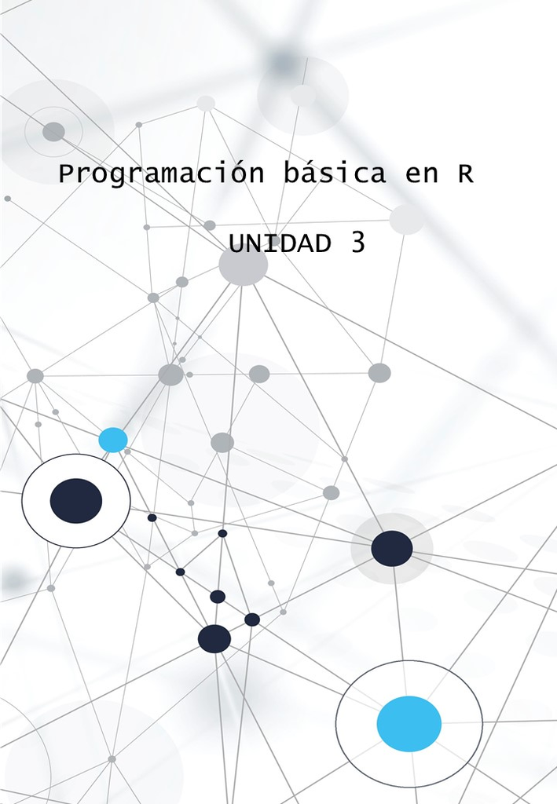

> **TEMAS CENTRALES DEL MÓDULO**

> Simulaciones de funciones de distribución

> La familia apply

> Definición de funciones propias

> Procesos iterativos

# 1 Introducción

## 1.1 Nota

Este capítulo está pensado para aquellos que no son programadores, pero les seria muy útil conocer algunas herramientas básicas de programación. A medida que vaya aprendiendo a programar en `R`, descubrirá progresivamente nuevas formas fascinantes de hacer las cosas que antes no se habría imaginado. Nunca se aprende a programar del todo.

Para profundizar en programación en `R` recomendamos por ejemplo bibliografía especifica como:

[figure not shown]

O, este otro libro está diseñado principalmente para usuarios de `R` que desean mejorar sus habilidades de programación y comprensión del lenguaje.

[figure not shown]

# 2 Simulaciones de funciones de distribución

La simulación de funciones de distribución puede aplicarse para:

- Análisis de Monte Carlo:

Puedes utilizar estas funciones para simular datos que siguen una determinada distribución y realizar análisis de Monte Carlo. Por ejemplo, si estás estudiando el comportamiento de un sistema financiero, puedes simular datos aleatorios de una distribución normal para representar los rendimientos diarios de una acción y luego realizar miles de simulaciones para evaluar el riesgo y la rentabilidad potencial.

- Pruebas de hipótesis:

Puedes generar datos aleatorios bajo una hipótesis nula y utilizarlos para realizar pruebas de hipótesis. Por ejemplo, si deseas probar si la media de una muestra es igual a cero, puedes generar datos aleatorios de una distribución normal con media cero y compararlos con tu muestra observada utilizando una prueba de hipótesis como la prueba t.

- Simulación de escenarios:

Puedes utilizar estas funciones para simular diferentes escenarios y evaluar el impacto de diferentes variables en un sistema o modelo. Por ejemplo, si estás construyendo un modelo de simulación para predecir el tiempo de espera en una cola de atención al cliente, puedes generar datos aleatorios de una distribución exponencial para simular los tiempos de llegada de los clientes y analizar cómo diferentes tasas de llegada afectan el tiempo de espera promedio.

- Estimación de parámetros:

Puedes utilizar estas funciones para generar datos sintéticos y ajustar modelos estadísticos para estimar los parámetros desconocidos. Por ejemplo, si estás ajustando un modelo lineal, puedes generar datos aleatorios siguiendo una distribución normal con ciertos parámetros, ajustar el modelo a los datos sintéticos y luego comparar los parámetros estimados con los verdaderos.

Podemos generar datos simulados bajo distintas funciones de distribución, algunos ejemplos son

| Distribución | Función en R | Tipo de distribución |
| --- | --- | --- |
| binomial | `binom()` | discreta |
| chi-squared | `chisq()` | continua |
| F | `f()` | continua |
| hypergeometric | `hyper()` | discreta |
| normal | `norm()` | continua |
| Poisson | `pois()` | discreta |
| Student’s t | `t()` | continua |
| uniform | `unif()` | continua |

`R` dispone de cuatro funciones de simulación de distribuciones. Se puede acceder a cada una de ellas simplemente precediendo el nombre de la distribución que figura en la tabla anterior por la letra que se indica a continuación:

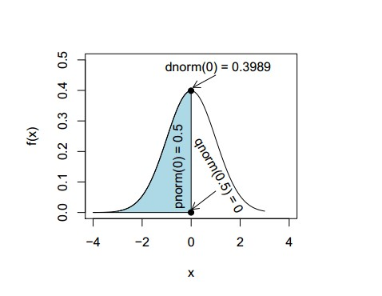

*r*: función para simular datos con dicha distribución. *d*: función de densidad o de probabilidad. *p*: función de distribución. *q*: función para el cálculo de cuantiles.

Combinando prefijos y sufijos, la función de *densidad** de una distribución normal se obtiene con `dnorm()`, la función de *distribución*** con `pnorm()`, los *cuantiles* se calculan mediante `qnorm()` y los *valores aleatorios* con distribución normal mediante `rnorm()`.

*La *función de densidad de probabilidad* de una variable aleatoria continua describe la probabilidad relativa de que dicha variable tome determinado valor.

**Para cualquier variable aleatoria $X$ evaluada en un valor $x$, la *función de distribución acumulada* describe la probabilidad de que $X$ tenga un valor menor o igual que $x$.

**Ejemplo: función de distribución normal**

```r
set.seed(100)
data<-rnorm(10000000, mean = 0, sd = 1)
mean(data)
```

```
## [1] -0.0001944567
```

```r
sd(data)
```

```
## [1] 1.000139
```

```r
dnorm(1, mean = 0, sd = 1)
```

```
## [1] 0.2419707
```

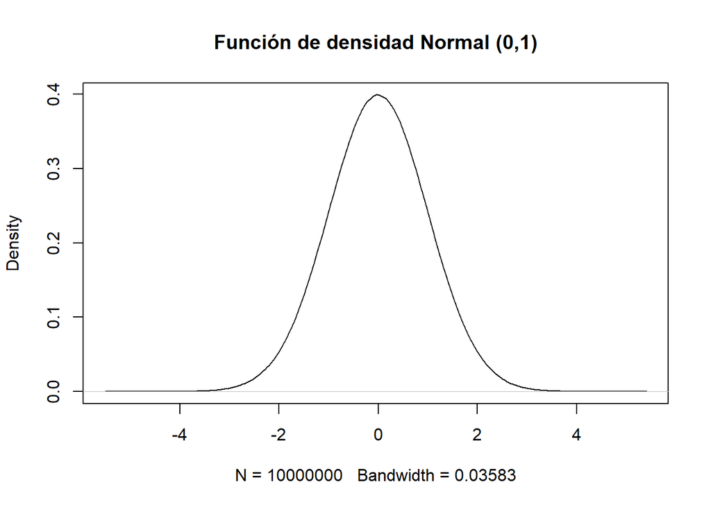

```r
plot(density(data), main="Función de densidad Normal (0,1)")
```

La función `rnorm()` genera una cantidad $x$ de valores al azar bajo una distribución Normal.

`set.seed(100)` sirve para que la simulación genere siempre el mismo conjunto de datos.

Con los siguientes gráficos se puede observar cómo al aumentar el número de observaciones (n), los histogramas de los datos se acercan a la función de densidad normal real:

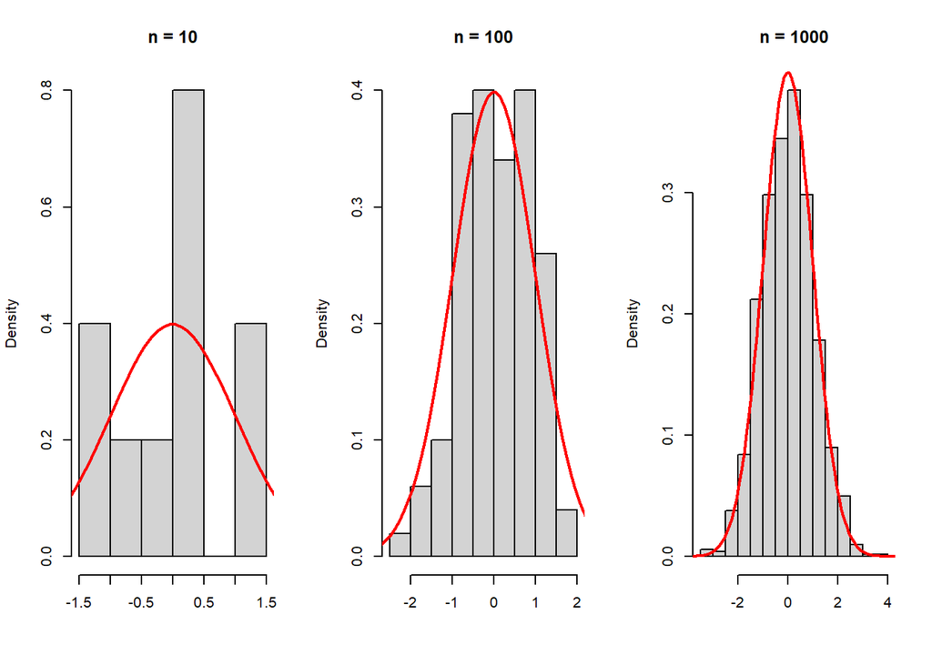

```r
par(mfrow = c(1, 3))# Dividimos la ventana gráfica en una fila y tres columnas
x <- seq(-10, 10, length = 200)
set.seed(3)# Semilla

# n = 10
hist(rnorm(10, mean = 0, sd = 1), main = "n = 10",
     xlab = "", prob = TRUE)
lines(x, dnorm(x), col = "red", lwd = 2)

# n = 100
hist(rnorm(100, mean = 0, sd = 1), main = "n = 100",
     xlab = "", prob = TRUE)
lines(x, dnorm(x), col = "red", lwd = 2)

# n = 1000
hist(rnorm(1000, mean = 0, sd = 1), main = "n = 1000",
     xlab = "", prob = TRUE)
lines(x, dnorm(x), col = "red", lwd = 2)
```

```r
# Volvemos a la ventana original
par(mfrow = c(1, 1))
```

**Ejemplo: Distribución normal cuantiles**

- No más tablas - ahora puede usar R!

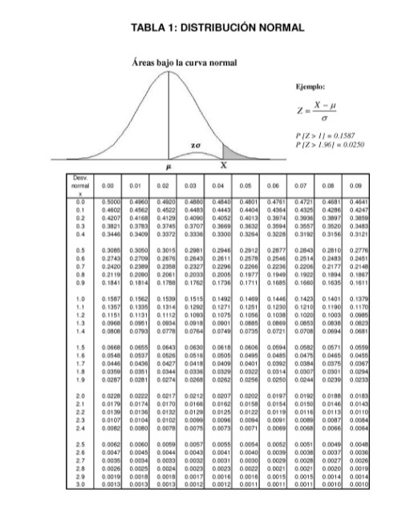

Figure 2.1: NO MAS TABLAS

Para obtener cuantiles o “valores críticos”, puede usar la función `qnorm()` como en los ejemplos siguientes.

```r
qnorm(0.95, mean = 0, sd = 1)
```

```
## [1] 1.644854
```

```r
qnorm(0.05, mean = 0, sd = 1)
```

```
## [1] -1.644854
```

```r
qnorm(0.99, mean = 0, sd = 1)
```

```
## [1] 2.326348
```

```r
qnorm(0.01, mean = 0, sd = 1)
```

```
## [1] -2.326348
```

# 3 La familia `apply`

Para ejemplificar como extraer valores de una base de datos, vamos a utilizar la base de datos **lluvia** que contiene datos de precipitación medidos en el tiempo de las estaciones agrometeorológicas de INTA.

[interactive chart not shown]

```r
library(readxl)
# 1.Leer los datos
lluvia<- read_excel("lluvia_pampa.xlsx")
names(lluvia)
```

```
##  [1] "localidad" "año"       "ene"       "feb"       "mar"       "abr"
##  [7] "may"       "jun"       "jul"       "ago"       "sep"       "oct"
## [13] "nov"       "dic"       "lat"       "long"      "altitud"
```

```r
summary(lluvia)
```

```
##   localidad              año            ene              feb
##  Length:1528        Min.   :1961   Min.   :  1.80   Min.   :  0.60
##  Class :character   1st Qu.:1973   1st Qu.: 57.98   1st Qu.: 49.67
##  Mode  :character   Median :1984   Median : 94.65   Median : 81.05
##                     Mean   :1984   Mean   :106.20   Mean   : 97.83
##                     3rd Qu.:1996   3rd Qu.:141.00   3rd Qu.:124.40
##                     Max.   :2008   Max.   :379.50   Max.   :691.50
##       mar              abr              may              jun
##  Min.   :  0.20   Min.   :  0.10   Min.   :  0.30   Min.   :  0.10
##  1st Qu.: 60.08   1st Qu.: 39.38   1st Qu.: 19.10   1st Qu.: 11.90
##  Median : 97.10   Median : 70.65   Median : 42.50   Median : 29.45
##  Mean   :115.69   Mean   : 86.43   Mean   : 53.82   Mean   : 40.54
##  3rd Qu.:152.70   3rd Qu.:114.00   3rd Qu.: 73.90   3rd Qu.: 58.42
##  Max.   :701.20   Max.   :601.20   Max.   :362.40   Max.   :328.60
##       jul              ago              sep              oct
##  Min.   :  0.10   Min.   :  0.10   Min.   :  0.20   Min.   :  0.5
##  1st Qu.: 11.88   1st Qu.: 13.00   1st Qu.: 23.50   1st Qu.: 54.0
##  Median : 31.10   Median : 31.70   Median : 45.85   Median : 87.0
##  Mean   : 39.18   Mean   : 42.59   Mean   : 55.82   Mean   :100.0
##  3rd Qu.: 57.70   3rd Qu.: 62.30   3rd Qu.: 78.00   3rd Qu.:131.6
##  Max.   :186.00   Max.   :383.60   Max.   :287.50   Max.   :449.8
##       nov              dic              lat              long
##  Min.   :  3.30   Min.   :  1.00   Min.   :-38.73   Min.   :-63.88
##  1st Qu.: 54.58   1st Qu.: 56.38   1st Qu.:-37.60   1st Qu.:-61.95
##  Median : 84.60   Median : 88.05   Median :-35.45   Median :-60.40
##  Mean   : 94.69   Mean   :104.28   Mean   :-35.46   Mean   :-60.39
##  3rd Qu.:128.00   3rd Qu.:137.05   3rd Qu.:-33.93   3rd Qu.:-58.65
##  Max.   :403.60   Max.   :724.70   Max.   :-31.67   Max.   :-57.58
##    altitud
##  Length:1528
##  Class :character
##  Mode  :character
##
##
##
```

La familia `apply`, tiene varios miembros: `apply`, `sapply`, `lapply`, `tapply`, y `mapply`, estas permiten simplificar la realización de algunos cálculos, que de otra forma se deberían programar utilizando `for` (bucles, que veremos más adelante)

Veremos como se utilizan las dos más usuales:

- `apply` se usa cuando desea aplicar una función sobre una matriz o `data.frame`. Suma valores por fila o columna
- `tapply` es una función que permite crear resúmenes de grupos basados en niveles de los factores.

La sintaxis de estas funciones es:

[output not shown]

los tres primeros argumentos son los más habituales:

`apply(matrix, 1/2, f)`

```
tapply(X,                # Objeto divisible (matriz, data frame, ...)
       INDEX,            # Lista(s) de factores de la misma longitud que X
       FUN,              # Función que se aplicará a los factores (o NULL)
       ...,              # Argumentos adicionales para pasar a FUN
       default = NA,     # Si simplify = TRUE, es el valor de inicialización del array
       simplify = TRUE)  # Si FALSE devuelve una lista
```

los tres primeros argumentos son los más habituales:

`tapply(vector, grouping, f)`

**Ejemplos de `apply`**

Por ejemplo, si sobre la base de datos **lluvia** quisiéramos saber ¿cuál fue el valor de lluvia máxima que se presentó en enero para todas las localidades? Recuerde que enero está en la columna 3, entonces las sentencias serian:

```r
a<-apply(lluvia[3], 2, max) #  2 indica columnas
a
```

```
##   ene
## 379.5
```

Para saber por ejemplo ¿Cuál fue el valor de lluvia máxima que se presentó en enero para Miramar?

```r
apply(lluvia[lluvia$localidad=="MIRAMAR",3 ],2,max)
```

```
## ene
## 236
```

¿Cuál fue el valor de lluvia máxima que se presentó en enero para “TRES ARROYOS-AERO”?

```r
apply(lluvia[lluvia$localidad=="TRES ARROYOS-AERO",3 ],2,max)
```

```
##   ene
## 253.5
```

**Ejemplos de `tapply`**

¿Cuál es la suma de las precipitaciones en el mes de enero en cada localidad?

Aplicamos una función a cada celda designada, en función de los niveles de ciertos factores.

```r
(tabla.1<-tapply(lluvia$ene, lluvia$localidad, sum))
```

```
##                        AZUL-AERO                BAHIA BLANCA-AERO
##                           4394.4                           2470.3
##                    BALCARCE-INTA                      BARROW-INTA
##                           4516.7                           3623.5
##                     BOLIVAR-AERO                   BORDENAVE-INTA
##                           3155.8                           3607.0
##                     BRAGADO-INTA             CANALS(INTA-CORDOBA)
##                           1524.0                           1535.0
##                    CASTELAR-INTA           CONC. del URUGUAY-INTA
##                           5178.6                           4979.5
##              CORONEL SUAREZ-AERO                     DOLORES-AERO
##                           3424.9                           4521.3
## DORREGO(EST.EL UNO)PP(S/TARROYO)                      EZEIZA-AERO
##                           1679.0                           4249.6
##                GENERAL PICO-AERO            GENERAL VILLEGAS-INTA
##                           3843.2                           3620.9
##                GUALEGUAYCHU-AERO              JUNIN-AERO (Bs.As.)
##                           5002.8                           5183.1
##       LA GUARDIA-ITALO-(CORDOBA)         LA MARTITA (DE LA GARMA)
##                            704.5                           3946.5
##                    LA PLATA-AERO                   LABOULAYE-AERO
##                           4668.4                           4290.4
##                  LAS FLORES-AERO                    MANFREDI-INTA
##                           3986.1                           2178.9
##               MAR DEL PLATA-AERO               MARCOS JUAREZ-AERO
##                           4228.7                           3733.5
##               MARCOS JUAREZ-INTA          MERCEDES (BUENOS AIRES)
##                           3722.8                           3009.3
##                          MIRAMAR              NUEVE DE JULIO-AERO
##                           2945.7                           5474.6
##                   OLAVARRIA-AERO                    OLIVEROS-INTA
##                           3332.6                           4864.0
##                      PARANA-AERO                      PARANA-INTA
##                           4777.6                           5025.1
##                     PEHUAJO-AERO                   PERGAMINO-INTA
##                           4099.6                           4688.4
##                       PIGUE-AERO                       PILAR-AERO
##                           2543.2                           3644.5
##                   SAN PEDRO-INTA                      TANDIL-AERO
##                           4657.4                           4481.1
## TORNQUIST(FUNQUE)T>T<PP(S/PIGUE)                TRES ARROYOS-AERO
##                           1947.9                           3490.2
##                   V.ORTUZAR-AERO
##                           5328.7
```

¿Cuál es la suma de las precipitaciones en el mes de enero en cada localidad antes de 1970?

```r
(tabla.2<-tapply(lluvia$ene[lluvia$año<1970], lluvia$localidad[lluvia$año<1970], sum))
```

```
##                        AZUL-AERO                BAHIA BLANCA-AERO
##                            546.7                            341.8
##                    BALCARCE-INTA                      BARROW-INTA
##                            412.0                            766.5
##                     BOLIVAR-AERO                   BORDENAVE-INTA
##                             49.0                            442.6
##                     BRAGADO-INTA             CANALS(INTA-CORDOBA)
##                            123.0                            464.0
##                    CASTELAR-INTA           CONC. del URUGUAY-INTA
##                            678.0                            769.8
##              CORONEL SUAREZ-AERO                     DOLORES-AERO
##                            317.7                            684.7
## DORREGO(EST.EL UNO)PP(S/TARROYO)                      EZEIZA-AERO
##                            230.0                            452.6
##                GENERAL PICO-AERO            GENERAL VILLEGAS-INTA
##                            283.1                            349.0
##                GUALEGUAYCHU-AERO              JUNIN-AERO (Bs.As.)
##                            481.0                            394.4
##       LA GUARDIA-ITALO-(CORDOBA)         LA MARTITA (DE LA GARMA)
##                            116.5                            667.0
##                    LA PLATA-AERO                   LABOULAYE-AERO
##                            610.8                            513.2
##                  LAS FLORES-AERO                    MANFREDI-INTA
##                            517.4                            341.9
##               MAR DEL PLATA-AERO               MARCOS JUAREZ-AERO
##                            739.4                            550.7
##               MARCOS JUAREZ-INTA              NUEVE DE JULIO-AERO
##                             57.6                            541.9
##                   OLAVARRIA-AERO                    OLIVEROS-INTA
##                            143.4                            438.1
##                      PARANA-AERO                      PARANA-INTA
##                            883.0                            664.8
##                     PEHUAJO-AERO                   PERGAMINO-INTA
##                            338.5                            646.5
##                       PIGUE-AERO                       PILAR-AERO
##                            371.4                            470.8
##                   SAN PEDRO-INTA                      TANDIL-AERO
##                            207.8                            553.8
## TORNQUIST(FUNQUE)T>T<PP(S/PIGUE)                TRES ARROYOS-AERO
##                            371.4                            779.4
##                   V.ORTUZAR-AERO
##                            705.0
```

¿Cuántos años tiene cada localidad ?

```r
(años.localidad <- tapply(lluvia$año,lluvia$localidad,  function(x) length(unique(x))))
```

```
##                        AZUL-AERO                BAHIA BLANCA-AERO
##                               40                               40
##                    BALCARCE-INTA                      BARROW-INTA
##                               43                               45
##                     BOLIVAR-AERO                   BORDENAVE-INTA
##                               27                               40
##                     BRAGADO-INTA             CANALS(INTA-CORDOBA)
##                               16                               13
##                    CASTELAR-INTA           CONC. del URUGUAY-INTA
##                               47                               45
##              CORONEL SUAREZ-AERO                     DOLORES-AERO
##                               39                               43
## DORREGO(EST.EL UNO)PP(S/TARROYO)                      EZEIZA-AERO
##                               21                               44
##                GENERAL PICO-AERO            GENERAL VILLEGAS-INTA
##                               32                               29
##                GUALEGUAYCHU-AERO              JUNIN-AERO (Bs.As.)
##                               44                               40
##       LA GUARDIA-ITALO-(CORDOBA)         LA MARTITA (DE LA GARMA)
##                                6                               35
##                    LA PLATA-AERO                   LABOULAYE-AERO
##                               44                               37
##                  LAS FLORES-AERO                    MANFREDI-INTA
##                               38                               15
##               MAR DEL PLATA-AERO               MARCOS JUAREZ-AERO
##                               44                               35
##               MARCOS JUAREZ-INTA          MERCEDES (BUENOS AIRES)
##                               32                               28
##                          MIRAMAR              NUEVE DE JULIO-AERO
##                               30                               42
##                   OLAVARRIA-AERO                    OLIVEROS-INTA
##                               36                               41
##                      PARANA-AERO                      PARANA-INTA
##                               42                               43
##                     PEHUAJO-AERO                   PERGAMINO-INTA
##                               38                               41
##                       PIGUE-AERO                       PILAR-AERO
##                               34                               27
##                   SAN PEDRO-INTA                      TANDIL-AERO
##                               38                               42
## TORNQUIST(FUNQUE)T>T<PP(S/PIGUE)                TRES ARROYOS-AERO
##                               28                               44
##                   V.ORTUZAR-AERO
##                               40
```

¿Cuántas localidades tuvieron más del 40 años de registros

```r
años.localidad[años.localidad >40]
```

```
##          BALCARCE-INTA            BARROW-INTA          CASTELAR-INTA
##                     43                     45                     47
## CONC. del URUGUAY-INTA           DOLORES-AERO            EZEIZA-AERO
##                     45                     43                     44
##      GUALEGUAYCHU-AERO          LA PLATA-AERO     MAR DEL PLATA-AERO
##                     44                     44                     44
##    NUEVE DE JULIO-AERO          OLIVEROS-INTA            PARANA-AERO
##                     42                     41                     42
##            PARANA-INTA         PERGAMINO-INTA            TANDIL-AERO
##                     43                     41                     42
##      TRES ARROYOS-AERO
##                     44
```

Como mencionamos anteriormente, no existe un forma única de lograr los resultados en R, según las situaciones podrían aplicarse una u otra librería y muchas veces se complementan. Entendemos que es importante conocer que existen distintos caminos, ya que al momento de abordar la literatura podremos encontrarnos con distintos enfoques. A continuación mostramos las formas alternativas que ofrece `library(tidyverse)` como opción a la familia `apply` de `library(base)`

```
__________________________________________________
# con library(base)
apply(lluvia[3], 2, max)

# con library(tidyverse)
lluvia %>% select(3) %>% max()
__________________________________________________
# con library(base)
apply(lluvia[lluvia$localidad=="MIRAMAR",3 ],2,max)

# con library(tidyverse)
lluvia %>%
  filter(localidad == 'MIRAMAR') %>%
  select(3) %>%
  max()
__________________________________________________
# con library(base)
apply(lluvia[lluvia$localidad=="TRES ARROYOS-AERO",3 ],2,max)

# con library(tidyverse)
lluvia %>%
  filter(localidad == 'TRES ARROYOS-AERO') %>%
  select(3) %>%
  max()
__________________________________________________
# con library(base)
tapply(lluvia$ene, lluvia$localidad, sum)

# con library(tidyverse)
lluvia %>% group_by(localidad) %>%
  summarise(total_enero = sum(ene))


__________________________________________________
# con library(base)
tapply(lluvia$ene[lluvia$año<1970], lluvia$localidad[lluvia$año<1970], sum)

# con library(tidyverse)
lluvia %>%
  filter(año<1970) %>%
  group_by(localidad) %>%
  summarise(total_enero = sum(ene))
__________________________________________________
# con library(base)
# ¿Cuántos años tiene cada localidad ?
tapply(lluvia$año,lluvia$localidad,  function(x) length(unique(x)))

# con library(tidyverse)
lluvia %>% group_by(localidad) %>%
  summarise(cantidad = n_distinct(año))
__________________________________________________
# con library(base)
# +40
#años.localidad[años.localidad >40]

# con library(tidyverse)
lluvia %>% group_by(localidad) %>%
  summarise(cantidad = n_distinct(año)) %>%
  filter(cantidad > 40)
```

¿Queres conocer al resto de los integrantes de la familia apply?

Investiga este enlace:https://bookdown.org/jboscomendoza/r-principiantes4/la-familia-apply.html

# 4 Definición de funciones propias

`R` también es un lenguaje de programación aunque se utilice poco para desarrollar programas largos con `R` al estilo de los que se crean con Java, C++ u otros lenguajes.

Normalmente programar `R` es crear funciones útiles en un contexto determinado: pueden crearse para ser utilizadas en un único proyecto o en una parte muy concreta o pequeña del mismo. También puede querer guardarlas para reutilizarlas en otros proyectos.

Las funciones programadas en R funciones puede que acaben en un propio paquetes de `R` y redistribuyéndolas entre sus colegas. No obstante, la creación de paquetes, aunque no es complicada, queda fuera del alcance de este curso. (Si te interesa el tema acá te dejamos este enlace:https://oscarperpinan.github.io/R/Paquetes.html)

```r
mi_suma <- function(a, b) {
  the_sum <- a + b
  return(the_sum)
}
```

El esquema de una funciones es: `function`, seguido de la lista de argumentos y de un bloque de código (encerrado en llaves) que contiene el cuerpo de la función.

Una función, típicamente, se asigna a una variable con <- Luego de definida puede invocarse asignado los valores que están entre paréntesis (a,b)

```r
mi_suma(3, 4)
```

```
## [1] 7
```

El bloque de código es un conjunto de líneas que se ejecutan secuencialmente y que se encierran con llaves {}. Sin embargo, no son necesarias cuando el bloque consiste en una sola línea. Por ejemplo;

```r
cuadrado <- function(x){
  return(x^2)
}

cuadrado(9)
```

```
## [1] 81
```

o

```r
cuadrado <- function(x) return(x^2)
cuadrado(9)
```

```
## [1] 81
```

Ambas definiciones son válidas de la función cuadrado.

Hemos usado `return` para que la función devuelva un valor. En algunos lenguajes de programación es obligatorio el uso de `return`; sin embargo, en `R` no: una función de `R` devuelve el último valor calculado dentro de su cuerpo. Así que una tercera opción equivalente y más sucinta para definir la función cuadrado es:

```r
cuadrado <- function(x) x^2
cuadrado(9)
```

```
## [1] 81
```

Las funciones en `R` pueden tener argumentos con valores por defecto. Por ejemplo,

```r
potencia <- function(x, exponente = 2) x^exponente
datos<-c(potencia(2), potencia(2, 3), potencia(2, exponente = 3))
datos
```

```
## [1] 4 8 8
```

# 5 Procesos iterativos

## 5.1 Bucle `for`

En la programación es habitual construir bucles dentro de los cuales se va modificando el valor de una expresión.

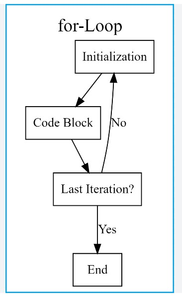

Al comienzo de cada bucle `for` hay un encabezado que define una colección de objetos, como los elementos de un vector o una lista.

La cabeza va seguida de un bloque de código (es decir, el cuerpo de nuestro ciclo). En este bloque podemos ejecutar básicamente cualquier sintaxis de R que queramos.

Posteriormente, el bucle `for` comprueba si llegó al último objeto de la colección especificado en la cabecera del bucle. Si este es el caso, el bucle `for` se detiene. Si este no es el caso, se repite el bloque de código dentro del bucle `for`.

Los bucles más habituales en R son los `for`. Su sintaxis es:

```
for (var in vector){
  # expresión que se repite
}
```

También se puede escribir así:

```
for (var in vector)  # expresión que se repite
```

Las llaves solo son obligatorias cuando el bloque de código contiene más de una línea.

## 5.2 Ejemplos del ciclo for en R

### 5.2.1 Ejemplo 1

```r
for (i in 1:5) {
   x1 <- i^2
  print(x1)
}
```

```
## [1] 1
## [1] 4
## [1] 9
## [1] 16
## [1] 25
```

### 5.2.2 Ejemplo 2

Queremos conocer la distribución de la media muestral de n observaciones obtenidas independientemente de una distribución uniforme a lo largo del intervalo (0, 1).

- Generar n observaciones con distribución uniforme en (0, 1).
- Calcular la media muestral de los datos.
- Repetir los pasos anteriores un elevado número de repeticiones.
- Aproximar la distribución de la media muestral con el histograma obtenido con las medias muestrales obtenidas en las repeticiones.

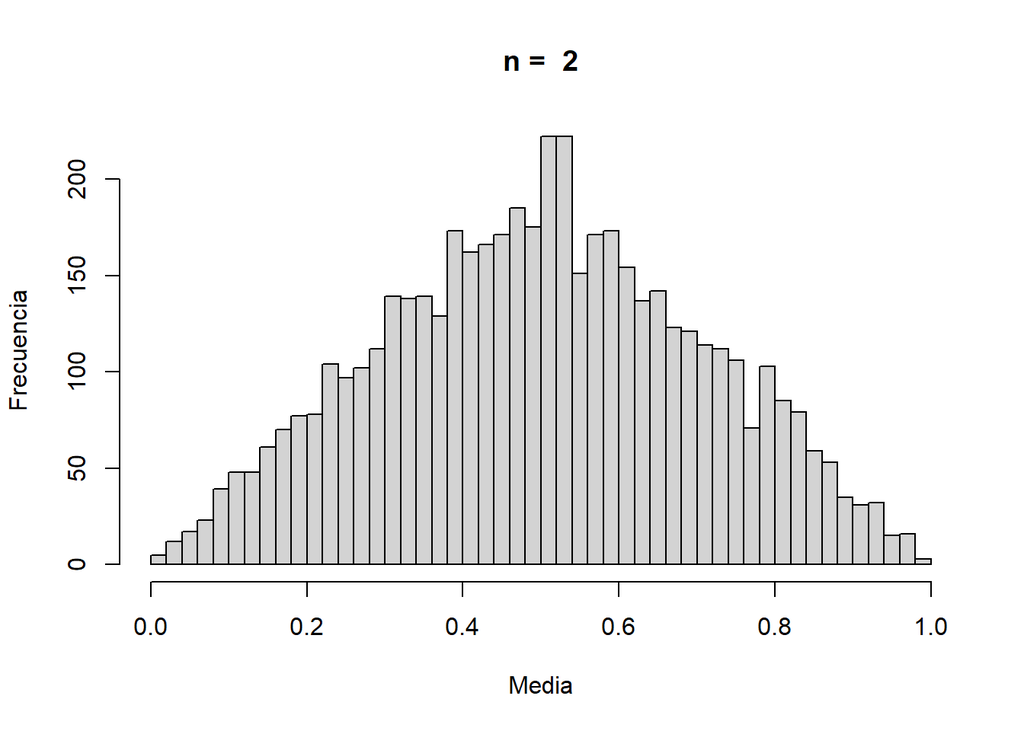

```r
set.seed(1)  # Fijamos semilla para reproductibilidad
rep <- 5000 # Número de repeticiones
n <- 2       # Número de puntos
Media<- numeric(rep)

for (i in 1:rep) {
    x <- runif(n)
    Media[i] <- mean(x)

}
hist(Media, breaks = 40, main = paste("n = ", n), ylab="Frecuencia")
```

### 5.2.3 Ejemplo 3

Imagina que tenemos este simple tibble:

```r
library(tidyverse)
df <- tibble(
  a = rnorm(10),
  b = rnorm(10),
  c = rnorm(10),
  d = rnorm(10)
)
df
```

```
## # A tibble: 10 × 4
##         a       b       c      d
##     <dbl>   <dbl>   <dbl>  <dbl>
##  1 -1.52  -0.808   0.343  -1.40
##  2  0.629  0.115   1.45   -1.18
##  3 -1.68  -0.180   1.35   -0.243
##  4  1.18   0.0548  0.475  -0.372
##  5  1.12   1.30   -0.249  -0.561
##  6 -1.24  -0.435  -1.44   -1.00
##  7 -1.23  -0.809  -0.984   0.884
##  8  0.598 -0.522  -1.19    0.194
##  9  0.299 -0.288  -0.0605 -1.52
## 10 -0.110 -0.643   1.95   -0.295
```

Queremos calcular la mediana de cada columna. Podrías hacerlo copiando y pegando el siguiente código:

```r
median(df$a)
```

```
## [1] 0.09436252
```

```r
median(df$b)
```

```
## [1] -0.3611385
```

```r
median(df$c)
```

```
## [1] 0.1411654
```

```r
median(df$d)
```

```
## [1] -0.4663724
```

Pero eso rompe una regla de oro: nunca copiar y pegar más de dos veces. En cambio, podríamos usar un bucle for:

```r
output <- vector("double", ncol(df))  # 1. output
for (i in seq_along(df)) {            # 2. secuencia
  output[[i]] <- median(df[[i]])      # 3. cuerpo
}
output
```

```
## [1]  0.09436252 -0.36113847  0.14116540 -0.46637236
```

### 5.2.4 Ejemplo 4

Veamos como usarlo en la base de datos lluvia, queremos obtener la suma de la precipitación de cada mes en cada localidad

```r
library(readxl)
lluvia.inta<- read_excel("lluvia_pampa.xlsx")
head(lluvia.inta)
```

```
## # A tibble: 6 × 17
##   localidad      año   ene   feb   mar   abr   may   jun   jul   ago   sep   oct
##   <chr>        <dbl> <dbl> <dbl> <dbl> <dbl> <dbl> <dbl> <dbl> <dbl> <dbl> <dbl>
## 1 MAR DEL PLA…  1961   142  34.5   109  42.5  30.5    15  55    138     25    72
## 2 MAR DEL PLA…  1962    82  85.5    74  91    21.5     5  25.8  162.   116    45
## 3 MAR DEL PLA…  1963    84 124     163   2.5  56      90 148     93     78   114
## 4 MAR DEL PLA…  1965   135  42      15  46    35     131  25    135      9    37
## 5 MAR DEL PLA…  1966    82 149      38  68    36     124  17     30     10    16
## 6 MAR DEL PLA…  1967    73  16      89  56    77      97  45     11     74   134
## # ℹ 5 more variables: nov <dbl>, dic <dbl>, lat <dbl>, long <dbl>,
## #   altitud <chr>
```

Vamos a acomodar los datos usando la función `pivot_longer` ver: vignette(“pivot”)

```r
# Pasa a 4 variables y elimina las ultima 3 columnas
lluvia <- lluvia.inta[-c(15:17)] %>% pivot_longer(!c(localidad, año),
                                             names_to = 'mes',
                                             values_to = 'ppm')
```

Este podría ser el código a usar:

```r
lluvia%>%
 filter(mes=="ene" & localidad=="MAR DEL PLATA-AERO" ) %>%
 summarise(total = sum(ppm))
```

```
## # A tibble: 1 × 1
##   total
##   <dbl>
## 1 4229.
```

Lo podemos convertir en una función

```r
precip<-function(data,lugar,fecha){
 data%>%
 filter(localidad==lugar & mes==fecha ) %>%
 summarise(total = sum(ppm))
}

precip(lluvia,"MAR DEL PLATA-AERO","ene")
```

```
## # A tibble: 1 × 1
##   total
##   <dbl>
## 1 4229.
```

Esta función la deberíamos aplicar a cada mes de cada localidad

```r
head(lugar<-unique(lluvia$localidad))
```

```
## [1] "MAR DEL PLATA-AERO"     "DOLORES-AERO"           "MIRAMAR"
## [4] "LA PLATA-AERO"          "CONC. del URUGUAY-INTA" "BALCARCE-INTA"
```

```r
head(meses<-unique(lluvia$mes))
```

```
## [1] "ene" "feb" "mar" "abr" "may" "jun"
```

Los podemos hacer usando un loop

```r
resultado<-data.frame()
for (i in lugar) {
  for (j in meses) {
sum.prep<- data.frame(precip(lluvia,i,j ), i, j)
resultado<-rbind(resultado,sum.prep)
  }
}
```

Para más ejemplos de loop ver: https://statisticsglobe.com/for-loop-in-r